# A Study on Flocking Behavior and Sexual Dimorphism in Taiwanese Birds

by

Ming-Pei Li 61143008S, Wei-Ting Sun 61343013S

Department of Life Science

Submitted in partial fulfillment of  
the requirements for the degree of

## Master

Faculty of , National Taiwan Normal University  
Taiwan

© Ming-Pei Li 61143008S, Wei-Ting Sun 61343013S

# 1 Introduction

## 1.1 Topic 1: Flocking behavior

Flocking behavior in birds enhances survival, with obligate flock species showing higher survival rates (Jullien & Clobert, 2000). Key drivers include predation avoidance and foraging efficiency (Jaime & Zuluaga, 2013). Birds in high predation areas form larger flocks, while island species with relaxed predation have reduced flocking, though foraging benefits may also play a role (Beauchamp, 2004; Jaime & Zuluaga, 2013). Human-altered landscapes affect flocking; habitat fragmentation reduces flock cohesion (Mokross et al., 2014), and urban areas support smaller flocks due to lower predation risk and consistent food sources (Carere et al., 2009; Jones et al., 2019). We hypothesize that anthropogenic habitats support less flocking than natural habitats.

## 1.2 Topic 2: Sexual Dimorphism

Research on plumage dimorphism in birds reveals its links to extra-pair paternity rates (Owens & Hartley, 1998), nest predation affecting female brightness (Martin & Badyaev, 1996), and social mating systems, with polygynous species showing greater dimorphism (Dunn et al., 2001). Color polymorphism, occurring in 3.5% of species, may result from selection under varying light conditions (Galeotti et al., 2003). Activity patterns influence eye morphology, with nocturnal species enhancing sensitivity and diurnal species improving acuity (Hall & Ross, 2007). Despite these insights, the relationship between avian activity time and plumage dimorphism remains unexplored. This study addresses this gap.

# 2 Methods

## 2.1 Steps for R code

Load the necessary packages.

```r
library (dplyr)
library (ggplot2)
library (tidyr)
library (mvabund)
bird_2 <- read.table ("dwca-trait_454-v1.68/measurementorfacts.txt", header = TRUE, sep = "\t", fill = TRUE)
bird_3 <-  read.table ("dwca-trait_454-v1.68/taxon.txt", header = TRUE, sep = "\t", quote = "", fill = TRUE)
```

*Hypothesis 1: Birds exhibit less flocking behavior in anthropogenic habitats compared to natural habitats, due to reduced predation risk and more stable food resource availability in anthropogenic environments.*

Filter the bird data for conspecific flocking behavior during the non-breeding season.

```r
co_flocks_nbd <- bird_2 %>% filter (measurementType %in% c("Flocks_ConspecificsNonBreedingSeason"))
```

Filter the bird data for non-territorial birds during the non-breeding season.

```r
nt_nbs <- bird_2 %>% filter (measurementType == "Territoriality_NonBreedingSeason" & measurementValue == 0)
```

Birds living in anthropogenic habitats are classified as ‘Anthropogenic habitat.’ Birds not living in these anthropogenic habitats are classified as ‘Natural habitat.’

```r
human_habitat <- bird_2 %>% filter (measurementType %in% c("Habitat_DrylandFarming", "Habitat_UrbanParks", "Habitat_UrbanRuralArea", "Habitat_AquaculturePonds", "Habitat_SaltExploitationSites", "Habitat_PaddyField") & measurementValue == 1) %>% mutate (habitat = "Anthropogenic habitat")

nonhuman_habitat <- bird_2 %>% filter (grepl ("Habitat", measurementType) & !(measurementType %in% c("Habitat_DrylandFarming", "Habitat_UrbanParks", "Habitat_UrbanRuralArea", "Habitat_AquaculturePonds", "Habitat_SaltExploitationSites", "Habitat_PaddyField")) & measurementValue == 1) %>% mutate (habitat = "Natural habitat")
```

Combine all habitat data and determine the primary habitat (either natural or anthropogenic) for each bird.

```r
maj_habitat <- rbind (nonhuman_habitat, human_habitat) %>% group_by (id, habitat) %>%tally () %>% group_by (id) %>% filter (n == max (n) & n != min(n)) %>% select (id, majority_habitat = habitat)
```

Merge flocking behavior data with primary habitat data and filter for non-territorial birds in the non-breeding season. Territorial birds, like eagles, do not flock during this period, so the analysis focuses on non-territorial species.

```r
co_flock_habitat <- co_flocks_nbd %>% inner_join (maj_habitat, by = "id") %>% inner_join(bird_3, by = "id") %>% filter (id %in% nt_nbs$id)
```

Categorical data can be analyzed using the Chi-square test or Fisher’s exact test, depending on assumptions. Both tests require categorical variables, independent observations, and mutually exclusive cells. If at least 80% of cells have an expected value ≥5, the Chi-square test is used; otherwise, Fisher’s exact test applies. The bird data meets the first three assumptions, so we calculate expected values to determine the appropriate test. Create a contingency table

```r
flock_table <- matrix(c(sum (co_flock_habitat$majority_habitat == "Natural habitat" & co_flock_habitat$measurementValue == 1), sum (co_flock_habitat$majority_habitat == "Anthropogenic habitat" & co_flock_habitat$measurementValue == 1), sum (co_flock_habitat$majority_habitat == "Natural habitat" & co_flock_habitat$measurementValue == 0), sum (co_flock_habitat$majority_habitat == "Anthropogenic habitat" & co_flock_habitat$measurementValue == 0)), nrow = 2, byrow = TRUE)
rownames (flock_table) <- c("Natural habitat", "Anthropogenic habitat")
colnames (flock_table) <- c("Yes (1)", "No (0)")
```

Print the contingency table

```r
print (flock_table)
```

```
##                       Yes (1) No (0)
## Natural habitat           114     18
## Anthropogenic habitat      75      2
```

Perform the Chi-squared test and obtain expected values

```r
chi_result <- chisq.test (flock_table)
print (chi_result$expected)
```

```
##                         Yes (1)    No (0)
## Natural habitat       119.36842 12.631579
## Anthropogenic habitat  69.63158  7.368421
```

All expected values exceed five, with counts: 119 (flocking, natural), 12 (no flocking, natural), 69 (flocking, anthropogenic), and 7 (no flocking, anthropogenic). Thus, we use the Chi-squared test to assess if flocking behavior differs between habitats. Use the Chi-squared test to whether bird flocking behavior significantly differs between natural and anthropogenic habitats.

```r
chisq.test (co_flock_habitat$measurementValue, co_flock_habitat$majority_habitat)
```

```
##
##  Pearson's Chi-squared test with Yates' continuity correction
##
## data:  co_flock_habitat$measurementValue and co_flock_habitat$majority_habitat
## X-squared = 5.6319, df = 1, p-value = 0.01764
```

The Generalized Linear Model (GLM) assumptions are: 1) independent observations of y, conditional on predictors x; 2) y follows a known distribution with a mean-variance relationship; 3) a linear relationship exists between the function g(y) and predictors x. The bird data meets the first assumption. However, a fan shape in the residuals plot violates the second assumption, so we decide not to use GLM.

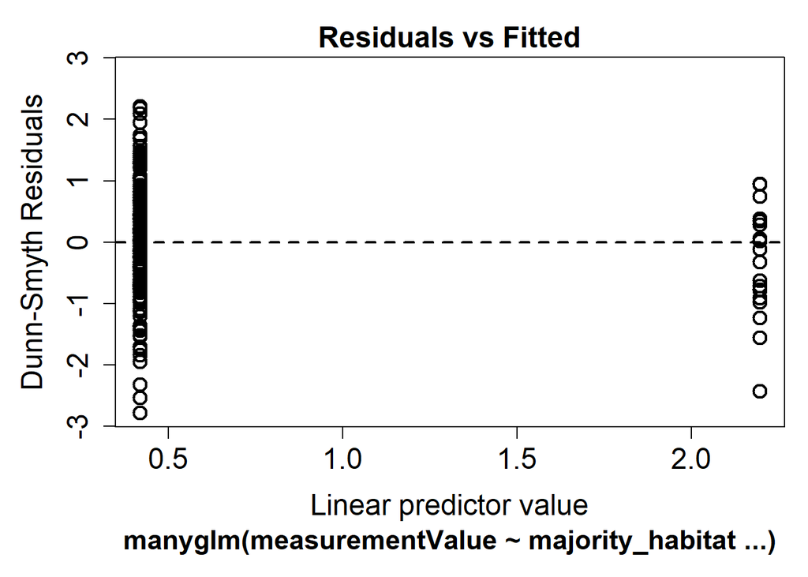

```r
bird.many <- manyglm (measurementValue ~ majority_habitat, family = "binomial", data = co_flock_habitat)
plot (bird.many)
```

Calculate the proportion of birds exhibiting flocking behavior in different habitats.

```r
stacked_data <- co_flock_habitat %>% group_by (majority_habitat, measurementValue) %>% summarise (count = n ()) %>% ungroup () %>% group_by (majority_habitat) %>% mutate (percentage = count / sum (count))
```

Plot the proportion of birds exhibiting flocking behavior by habitat type using a stacked bar chart.

[figure not shown]

```r
ggplot(stacked_data, aes(x = majority_habitat, y = percentage, fill = as.factor (measurementValue))) + geom_bar(stat = "identity", position = "stack", width = 0.6) + scale_fill_manual(values = c("1" = "skyblue", "0" = "lightcoral"), labels = c("1 (Flocking)", "0 (No Flocking)"), name = "Flocking Behavior") + labs(title = "Flocking Behavior by Habitat", x = "Habitat Type", y = "Proportion") +scale_y_continuous (limits = c(0, 1.1), breaks = seq (0, 1, 0.2), labels = c("0.00", "0.20", "0.40", "0.60", "0.80", "1.00")) + theme_minimal() + theme (legend.position = "top", panel.grid.minor.y = element_blank (), panel.grid.major.x = element_blank (), plot.title = element_text (hjust = 0.5, size = 16), plot.margin = margin (20, 20, 20, 20), axis.title.x = element_text (margin = margin(t = 15), size = 12), axis.title.y = element_text (margin = margin(r = 10), size = 12), axis.text.x = element_text (size = 12), axis.text.y = element_text (size = 12)) + annotate ("text", x = 1.5, y = 1.1, label = "*", size = 6, color = "black") + annotate ("segment", x = 1, xend = 2, y = 1.05, yend = 1.05, color = "black", linewidth = 0.5) + annotate ("text", x = 2, y = 0.1, label = "n = 189", size = 4, color = "black") + annotate ("text", x = 1, y = 0.1, label = "n = 20", size = 4, color = "black")
```

*Hypothesis 2: There is more plumage dimorphism in diurnal versus nocturnal birds.*

```r
Dimorphism_ActivityTime <- subset(bird_2, grepl("Dimorphism|ActivityTime", measurementType))
Dimorphism_ActivityTime_1 <- Dimorphism_ActivityTime %>% separate(col = "measurementType", sep = "_", into = c("measurement", "Type"))
Dimorphism <- Dimorphism_ActivityTime_1 %>% filter(measurement=="Dimorphism" & Type=="Plumage")
Dimorphism_1 <- Dimorphism %>% select(-measurement, -Type) %>% rename("Plumage"=measurementValue)
ActivityTime <- Dimorphism_ActivityTime_1 %>% filter(measurement=="ActivityTime" & measurementValue==1)
ActivityTime_1 <- ActivityTime %>% select(id, Type)
bird_dim_act <- merge(Dimorphism_1, ActivityTime_1, by = "id")
```

Categorical data can be analyzed using the Chi-square test, Fisher’s exact test, and Generalized Linear Model. We need to check whether the assumptions of each test are satisfied by the bird data. Create a contingency table

```r
flock_table_2 <- matrix( c(sum (bird_dim_act$Type == "Diurnal" & bird_dim_act$Plumage == 1), sum (bird_dim_act$Type == "Nocturnal" & bird_dim_act$Plumage == 1), sum (bird_dim_act$Type == "Diurnal" & bird_dim_act$Plumage == 0), sum (bird_dim_act$Type == "Nocturnal" & bird_dim_act$Plumage == 0)), nrow = 2, byrow = TRUE)
rownames (flock_table) <- c("Diunral", "Nocturnal")
colnames (flock_table) <- c("Yes (1)", "No (0)")
```

Print the contingency table

```r
print (flock_table_2)
```

```
##      [,1] [,2]
## [1,]  140   36
## [2,]  302   71
```

Perform the Chi-squared test and obtain expected values

```r
chi_result_2 <- chisq.test (flock_table_2)
print (chi_result_2$expected)
```

```
##          [,1]     [,2]
## [1,] 141.6976 34.30237
## [2,] 300.3024 72.69763
```

```r
chisq.test (bird_dim_act$Type, bird_dim_act$Plumage) # p-value = 0.7822
```

```
##
##  Pearson's Chi-squared test with Yates' continuity correction
##
## data:  bird_dim_act$Type and bird_dim_act$Plumage
## X-squared = 0.076443, df = 1, p-value = 0.7822
```

The bird data fits the first assumption of GLM. To check the second assumption of GLM, we examined a plot of the residuals and observed a fan shape in the bird data. Therefore, we decided not to use GLM to analyze the bird data.

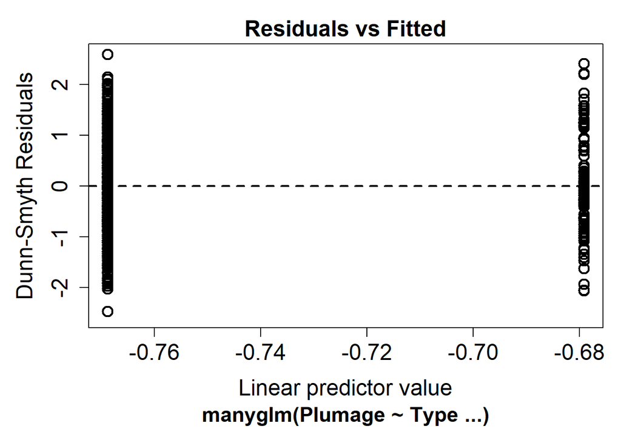

```r
bird.many_2 <- manyglm (Plumage~Type, family = "binomial", data = bird_dim_act)
plot (bird.many_2)
```

Plot the proportion of birds exhibit plumage dimorphism by different active times using a stacked bar chart.

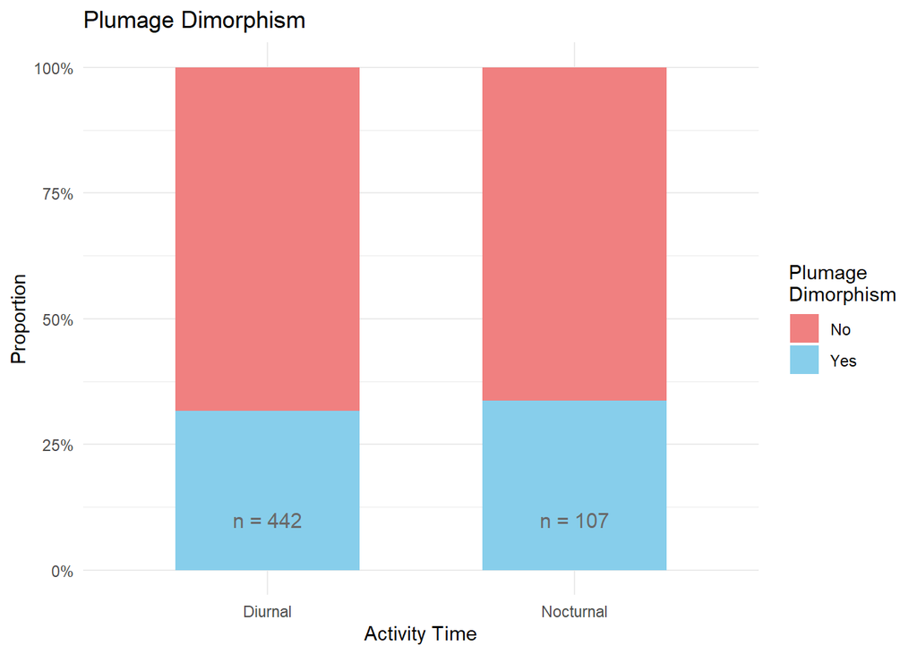

```r
ggplot(bird_dim_act, aes(x = Type, fill = as.factor(Plumage))) + geom_bar(position = "fill", width = 0.6) + labs( title = "Plumage Dimorphism", x = "Activity Time", y = "Proportion", fill = "Plumage\nDimorphism") + scale_fill_manual(values = c("1" = "skyblue", "0" = "lightcoral"),labels = c("0" = "No", "1" = "Yes"))+ scale_y_continuous(labels = scales::percent_format()) + theme_minimal()+ annotate ("text", x = 2, y = 0.1, label = "n = 107", size = 4, color = "dimgray") + annotate ("text", x = 1, y = 0.1, label = "n = 442", size = 4, color = "dimgray")
```

# 3 Results

## 3.2 Topic 2: Sexual Dimorphism

Figure 2 shows no significant difference in bird plumage color dimorphism across different activity times. The Chi-squared test results indicate no significant association (χ² = 0.07, df = 1, p = 0.78).

# 4 Discussion

## 4.2 Topic 2: Sexual Dimorphism

The results show no significant difference in plumage color dimorphism across different activity times in Taiwanese birds, possibly due to the influence of multiple indistinguishable factors. Sexual dimorphism in birds is shaped by social mating systems, with polygynous and lekking species exhibiting greater dimorphism than monogamous ones (Dunn et al., 2001). Plumage-color dimorphism relates to extra-pair paternity, while size dimorphism aligns with mating systems and parental care (Owens & Hartley, 1998). Sperm competition (testis size) influences tail and wing length dimorphism but is a weaker predictor of plumage dimorphism (Dunn et al., 2001). Geographic and life history factors also play roles (Dunn et al., 2001).

# 5 References

Barbosa, A. (1997). The effects of predation risk on scanning and flocking behavior in dunlin. https://digital.csic.es/handle/10261/9360

Beauchamp, G. (2004). Reduced Flocking by Birds on Islands with Relaxed Predation. Proceedings: Biological Sciences, 271(1543), 1039–1042.

Brown, J. A., Lerman, S. B., Basile, A. J., Bateman, H. L., Deviche, P., Warren, P. S., & Sweazea, K. L. (2022). No fry zones: How restaurant distribution and abundance influence avian communities in the Phoenix, AZ metropolitan area. PLOS ONE, 17(10), e0269334. https://doi.org/10.1371/journal.pone.0269334

Carere, C., Montanino, S., Moreschini, F., Zoratto, F., Chiarotti, F., Santucci, D., & Alleva, E. (2009). Aerial flocking patterns of wintering starlings, Sturnus vulgaris, under different predation risk. Animal Behaviour, 77(1), 101–107. https://doi.org/10.1016/j.anbehav.2008.08.034

Dunn, P. O., Whittingham, L. A., & Pitcher, T. E. (2001). MATING SYSTEMS, SPERM COMPETITION, AND THE EVOLUTION OF SEXUAL DIMORPHISM IN BIRDS. Evolution, 55(1), 161–175. https://doi.org/10.1111/j.0014-3820.2001.tb01281.x

Galeotti, P., Rubolini, D., Dunn, P. O., & Fasola, M. (2003). Colour polymorphism in birds: Causes and functions. Journal of Evolutionary Biology, 16(4), 635–646. https://doi.org/10.1046/j.1420-9101.2003.00569.x

Gering, J.C. and Blair, R.B. (1999), Predation on artificial bird nests along an urban gradient: predatory risk or relaxation in urban environments?. Ecography, 22: 532-541. https://doi.org/10.1111/j.1600-0587.1999.tb01283.x

Hall, M. I., & Ross, C. F. (2007). Eye shape and activity pattern in birds. Journal of Zoology, 271(4), 437–444. https://doi.org/10.1111/j.1469-7998.2006.00227.x

Jaime, G., & Zuluaga, C.J. (2013). WHY ANIMALS COME TOGETHER, WITH THE SPECIAL CASE OF MIXED-SPECIES BIRD FLOCKS.

Jones, T. B., Evans, J. C., & Morand-Ferron, J. (2019). Urbanization and the temporal patterns of social networks and group foraging behaviors. Ecology and Evolution, 9(8), 4589–4602. https://doi.org/10.1002/ece3.5060

Jullien, M., & Clobert, J. (2000). The Survival Value of Flocking in Neotropical Birds: Reality or Fiction? Ecology, 81(12), 3416–3430. https://doi.org/10.1890/0012-9658(2000)081[3416:TSVOFI]2.0.CO;2

Martin, T. E., & Badyaev, A. V. (1996). SEXUAL DICHROMATISM IN BIRDS: IMPORTANCE OF NEST PREDATION AND NEST LOCATION FOR FEMALES VERSUS MALES. Evolution, 50(6), 2454–2460. https://doi.org/10.1111/j.1558-5646.1996.tb03631.x

Mokross, K., Ryder, T. B., Côrtes, M. C., Wolfe, J. D., & Stouffer, P. C. (2014). Decay of interspecific avian flock networks along a disturbance gradient in Amazonia. Proceedings of the Royal Society B: Biological Sciences, 281(1776), 20132599. https://doi.org/10.1098/rspb.2013.2599

Owens, I. P. F., & Hartley, I. R. (1998). Sexual dimorphism in birds: Why are there so many different forms of dimorphism? Proceedings of the Royal Society of London. Series B: Biological Sciences, 265(1394), 397–407. https://doi.org/10.1098/rspb.1998.0308

Rodewald, A. D., Kearns, L. J., & Shustack, D. P. (2011). Anthropogenic resource subsidies decouple predator-prey relationships. Ecological Applications: A Publication of the Ecological Society of America, 21(3), 936–943. https://doi.org/10.1890/10-0863.1